# 00 start here · Jev learning lab

Skip to lesson content

Show Python code

Reading mode keeps the saved results visible. Open the notebook in Jupyter to run or change code.

**In this lesson**

- The idea in one minute
- Try one decision — no model call
- Choose your starting path
- Read first; run when ready
- How to study a lesson
- Three labels that keep the course honest
- A tiny Python reading guide
- Ready for lesson 01?
- Check your understanding
- Paper references

# Start here · Learn Jev one decision at a time

**Path:** Start here  
**Before you start:** No Python or machine learning background needed

Course home · Course outline · Setup help · Glossary

This is an **independent learning resource**, not official TypeSafe documentation. You do not need to know machine learning to start. The first path uses ordinary language and small examples.

## The idea in one minute

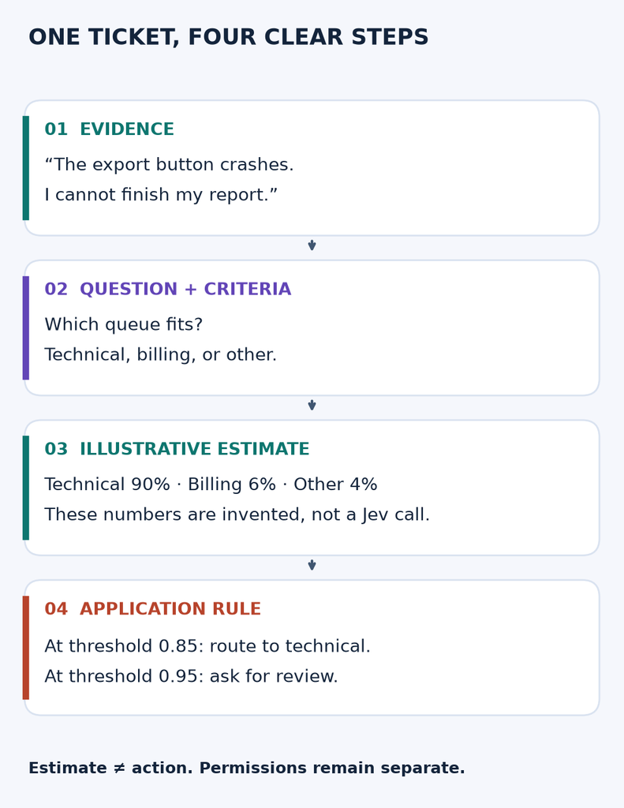

```python
# Find the included teaching helpers from the course folder.
from pathlib import Path
import sys
REQUIRED_FILES = ("src/lab_core.py", "src/tutorial_utils.py", "src/torch_lab.py",
                  "data/tickets.json", "data/torch_toy.json",
                  "assets/decision-flow.png", "assets/question-types.png",
                  "assets/calibration-counts.png", "assets/data-splits.png", "assets/word-order.png",
                  "assets/model-history-mobile.png")
COURSE_ROOT = next((p for p in (Path.cwd(), *Path.cwd().parents)
                    if all((p / name).is_file() for name in REQUIRED_FILES)), None)
# Colab opens a single notebook; fetch its companion code and fictional data.
if COURSE_ROOT is None:
    try:
        import google.colab
    except ImportError:
        pass
    else:
        import subprocess
        COURSE_ROOT = Path("/content/jev-learning-course")
        if COURSE_ROOT.exists() and not all((COURSE_ROOT / name).is_file() for name in REQUIRED_FILES):
            raise FileNotFoundError("The cached Colab course is incomplete. Start a fresh runtime and run all again.")
        if not COURSE_ROOT.exists():
            subprocess.run(["git", "clone", "--depth", "1",
                            "https://github.com/Optimizer077/jev-learning-course.git",
                            str(COURSE_ROOT)], check=True)
if COURSE_ROOT is None:
    raise FileNotFoundError("Extract the complete course and open it from its folder.")
if str(COURSE_ROOT / "src") not in sys.path:
    sys.path.insert(0, str(COURSE_ROOT / "src"))

from tutorial_utils import show_diagram
show_diagram('decision-flow', 'A message and a focused question lead to an illustrative estimate; application thresholds decide whether to route or review.')
```

Imagine this support message: **“The export button crashes. I cannot finish my report.”** We want to decide which team should help. A decision model can estimate how well each allowed queue fits the message. Our software then chooses a queue or asks someone to review the case.

Jev is TypeSafe AI's model for this kind of bounded judgment. It accepts state and typed questions. Its output is designed for software to use. [Official introduction](https://docs.typesafe.ai/introduction).

## Try one decision — no model call

The probabilities below are invented for teaching. “0.90” means 90%. Our example rule uses a threshold of 0.85. Before running, predict whether the message will be routed or reviewed.

**Math companion · optional first look**

For $K$ mutually exclusive answers, a probability vector satisfies $$p_k\geq0,\qquad \sum_{k=0}^{K-1}p_k=1.$$ Here $k$ is an answer index and $p_k$ is its probability. A larger value means more probability on that answer. This equation checks accounting, not truth or calibration. For example, $(0.06,0.90,0.04)$ sums to one but can still predict the wrong queue. The distinction between accurate labels and calibrated probabilities is studied by [Guo et al. (2017)](https://proceedings.mlr.press/v70/guo17a.html).

```python
probabilities = {'technical': 0.90, 'billing': 0.06, 'other': 0.04}
best_queue = max(probabilities, key=probabilities.get)
threshold = 0.85  # Teaching choice, not a recommended production setting.
action = best_queue if probabilities[best_queue] >= threshold else 'review'
print('Most likely queue:', best_queue)
print('What our program does:', action)
```

```
Most likely queue: technical
What our program does: technical
```

**What you should see:** `technical` for both lines. The model estimate and the software rule are separate steps. Changing the threshold to 0.95 changes the action to `review`, while the most likely queue stays `technical`. A real model's prediction can still be wrong.

## Choose your starting path

| You want to… | Start with… | What you can skip at first |
| --- | --- | --- |
| Understand the idea without coding | 01 · Basics → 04 · Workflows | All code and equations |
| Try changing numbers | 03 · Calibration | The optional math extensions |
| Learn how a small model is trained | 02 · From scratch | Lesson 06 until later |
| Build a complete local project | 02 → 03 → 07 · Text routing | The live API lesson |
| Call real Jev | 01 → 05 · Optional API | The architecture lab |
| Train several small neural models | 02 → 07 → 10 · PyTorch lab | Live API access and a GPU |

The lesson numbers are reference labels, not a requirement to finish every lesson in sequence. There are eleven notebooks, including this welcome, the worked solutions, and an optional related-models lab.

## Read first; run when ready

You have four ways to use the course:

1. **Read on GitHub.** Start at README.md, then follow the lesson links. The notebooks include saved explanations, charts, and results. Use the course outline for checkpoints.
2. **Run in Colab.** Use the **Open in Colab** button above, then choose **Runtime → Run all**. The first cell fetches the included course helpers and fictional data. A CPU runtime is sufficient.
3. **Run locally.** Follow SETUP.md, open the whole extracted folder in JupyterLab, and choose **Restart Kernel and Run All**. No API key or GPU is needed for the local lessons.
4. **Use an optional browser copy.** After downloading the folder, open `site/index.html` locally. Its reading mode hides code while keeping saved results. GitHub itself displays HTML files as source.

### What is a notebook cell?

A notebook alternates between explanations and runnable pieces of Python called **cells**. Select a code cell and press **Shift+Enter** to run it. Its result appears below. Run from top to bottom because later cells may use names created earlier. If a result looks stale after editing, restart the kernel (the Python session) and run all cells again.

## How to study a lesson

**Read → predict → run or inspect → explain.** Begin with the plain-language idea, predict one small change, inspect the result, and explain what happened in one sentence. Use “Check your understanding” before reading its answer. Optional deep dives can wait.

## Three labels that keep the course honest

| Label | Meaning |
| --- | --- |
| **Documented Jev behavior** | A statement linked to TypeSafe's public documentation |
| **General ML mechanism** | A small example of a method used in machine learning; not a Jev implementation |
| **Teaching data** | Invented examples, probabilities, or costs; not measured Jev results |

The detailed Jev architecture and RLCD training recipe are not supplied by the public pages reviewed. We explain useful mechanisms without filling those gaps with guesses. The only real API call is disabled by default in lesson 05. Sources.

## A tiny Python reading guide

| You see… | Read it as… |
| --- | --- |
| `x = 0.8` | Store the value 0.8 under the name x |
| `{'yes': 0.8, 'no': 0.2}` | A dictionary: named values |
| `[0.8, 0.2]` | A list of values in order |
| `if p >= 0.8:` | Run the next indented lines when p is at least 0.8 |
| `assert condition` | Check that an expected property holds; stop if it does not |
| `np.array(...)` | A NumPy array for numerical calculations |

## Ready for lesson 01?

You are ready if you can say: **“The model estimates. The program chooses what to do.”** You do not need to understand matrices, attention, or training yet.

Open lesson 01 · The basics.

Try the practice questions after lesson 01, or use the learning plan to organize several short sessions.

## Check your understanding

Do I need an API key to begin?

Pause and explain your answer before opening the explanation.

**Show the explanation**

No. All reading, plots, and local experiments work without one. The optional live call is in lesson 05.

For a short next step, try the practice questions. For runnable exercises, use the worked exercises.

If you are unsure where to go next, use the course outline.

Assignments · Quick reference · Course outline

## Paper references

Read these for the general methods used or contrasted in this lesson. They do not establish Jev’s unpublished architecture or RLCD algorithm. The formulas above are code-matched teaching notation unless explicitly attributed.

- **Guo et al. (2017).** [On Calibration of Modern Neural Networks](https://proceedings.mlr.press/v70/guo17a.html). ICML, PMLR 70:1321–1330. Temperature scaling and the difference between accuracy and calibration.
- **Brier (1950).** Verification of Forecasts Expressed in Terms of Probability. Monthly Weather Review 78(1):1–3. The original probability-forecast scoring paper; this course states its binary and multiclass conventions explicitly.

Paper reading guide and equation map · Jev documentation and source limits.